# N736 Homework 5 - Answer Key in R Markdown

Melinda K. Higgins, PhD.

November 13, 2017

## Create Data subset and recode variables

The R code chunk below selects the variables we want for this lesson:

- DV: `indtot`
- IV: `mcs`
- CV: `pss_fr` or `female`

The code also recodes `female` to `male` by flipping the 0,1 and let’s mean center `mcs` and `pss_fr` since we’ll also look at the interaction between these variables plus the interactions between `mcs` and gender (e.g. `female` or `male`).

```r
help2 <- help1 %>%
  dplyr::select(indtot, mcs, pss_fr, female) %>%
  dplyr::mutate(mcsC = mcs - mean(mcs),
         pss_frC = pss_fr - mean(pss_fr),
         male = as.numeric((female==0)),
         mcsC_x_pss_frC = mcsC * pss_frC,
         mcsC_x_female = mcsC * female,
         mcsC_x_male = mcsC * male)
```

## Run regression with interaction terms

Using a regression approach - look at `pss_fr` as a covariate for the relationship between `indtot` and `mcs` note the use of `*` which computes the interaction for you.

```r
# use lm for the regression model
m1 <- lm(indtot ~ mcsC * pss_frC, data=help2)

# simple summary of the model results
summary(m1)
```

```
##
## Call:
## lm(formula = indtot ~ mcsC * pss_frC, data = help2)
##
## Residuals:
##     Min      1Q  Median      3Q     Max
## -26.836  -3.461   1.195   4.324  12.361
##
## Coefficients:
##                Estimate Std. Error t value Pr(>|t|)
## (Intercept)  35.7349881  0.3105632 115.065  < 2e-16 ***
## mcsC         -0.2000313  0.0245551  -8.146 3.76e-15 ***
## pss_frC      -0.2645569  0.0779336  -3.395 0.000748 ***
## mcsC:pss_frC -0.0009228  0.0058256  -0.158 0.874213
## ---
## Signif. codes:  0 '***' 0.001 '**' 0.01 '*' 0.05 '.' 0.1 ' ' 1
##
## Residual standard error: 6.552 on 449 degrees of freedom
## Multiple R-squared:  0.1664, Adjusted R-squared:  0.1608
## F-statistic: 29.88 on 3 and 449 DF,  p-value: < 2.2e-16
```

```r
# more verbose summary of results using olsrr package
# this looks more like SPSS or SAS type output
olsrr::ols_regress(m1)
```

```
##                         Model Summary
## --------------------------------------------------------------
## R                       0.408       RMSE                6.552
## R-Squared               0.166       Coef. Var          18.338
## Adj. R-Squared          0.161       MSE                42.926
## Pred R-Squared          0.147       MAE                 4.957
## --------------------------------------------------------------
##  RMSE: Root Mean Square Error
##  MSE: Mean Square Error
##  MAE: Mean Absolute Error
##
##                                 ANOVA
## ----------------------------------------------------------------------
##                  Sum of
##                 Squares         DF    Mean Square      F         Sig.
## ----------------------------------------------------------------------
## Regression     3847.759          3       1282.586    29.879    0.0000
## Residual      19273.843        449         42.926
## Total         23121.603        452
## ----------------------------------------------------------------------
##
##                                    Parameter Estimates
## ------------------------------------------------------------------------------------------
##        model      Beta    Std. Error    Std. Beta       t        Sig      lower     upper
## ------------------------------------------------------------------------------------------
##  (Intercept)    35.735         0.311                 115.065    0.000    35.125    36.345
##         mcsC    -0.200         0.025       -0.359     -8.146    0.000    -0.248    -0.152
##      pss_frC    -0.265         0.078       -0.148     -3.395    0.001    -0.418    -0.111
## mcsC:pss_frC    -0.001         0.006       -0.007     -0.158    0.874    -0.012     0.011
## ------------------------------------------------------------------------------------------
```

Using the `aov` function - analysis of variance approach

```r
m1aov <- aov(indtot ~ mcsC * pss_frC, data=help2)
summary(m1aov)
```

```
##               Df Sum Sq Mean Sq F value   Pr(>F)
## mcsC           1   3350    3350  78.034  < 2e-16 ***
## pss_frC        1    497     497  11.578 0.000727 ***
## mcsC:pss_frC   1      1       1   0.025 0.874213
## Residuals    449  19274      43
## ---
## Signif. codes:  0 '***' 0.001 '**' 0.01 '*' 0.05 '.' 0.1 ' ' 1
```

```r
olsrr::ols_regress(m1aov)
```

```
##                         Model Summary
## --------------------------------------------------------------
## R                       0.408       RMSE                6.552
## R-Squared               0.166       Coef. Var          18.338
## Adj. R-Squared          0.161       MSE                42.926
## Pred R-Squared          0.147       MAE                 4.957
## --------------------------------------------------------------
##  RMSE: Root Mean Square Error
##  MSE: Mean Square Error
##  MAE: Mean Absolute Error
##
##                                 ANOVA
## ----------------------------------------------------------------------
##                  Sum of
##                 Squares         DF    Mean Square      F         Sig.
## ----------------------------------------------------------------------
## Regression     3847.759          3       1282.586    29.879    0.0000
## Residual      19273.843        449         42.926
## Total         23121.603        452
## ----------------------------------------------------------------------
##
##                                    Parameter Estimates
## ------------------------------------------------------------------------------------------
##        model      Beta    Std. Error    Std. Beta       t        Sig      lower     upper
## ------------------------------------------------------------------------------------------
##  (Intercept)    35.735         0.311                 115.065    0.000    35.125    36.345
##         mcsC    -0.200         0.025       -0.359     -8.146    0.000    -0.248    -0.152
##      pss_frC    -0.265         0.078       -0.148     -3.395    0.001    -0.418    -0.111
## mcsC:pss_frC    -0.001         0.006       -0.007     -0.158    0.874    -0.012     0.011
## ------------------------------------------------------------------------------------------
```

## Effect Plot

Also make the effectplot showing the interaction or lack thereof between `mcs` and `pss_fr` for `indtot`.

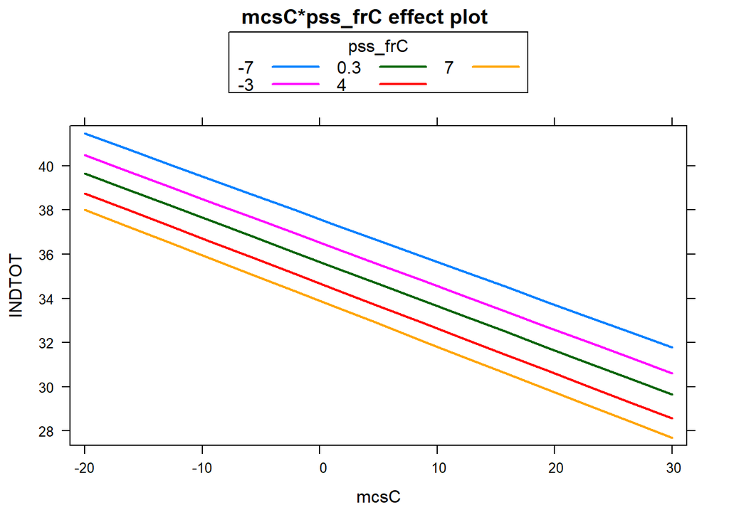

```r
plot(effects::effect("mcsC:pss_frC", m1,
            xlevels=list()),
     multiline=TRUE, ylab="INDTOT", rug=FALSE)
```

## Look at gender as a covariate

Now let’s look at gender as a covariate first run for `female` then run for `male` - compare the coding effect on the resulting model coefficients.

```r
m2f <- lm(indtot ~ mcsC * female, data=help2)
summary(m2f)
```

```
##
## Call:
## lm(formula = indtot ~ mcsC * female, data = help2)
##
## Residuals:
##      Min       1Q   Median       3Q      Max
## -28.5549  -3.1409   0.9924   4.3290  12.4871
##
## Coefficients:
##             Estimate Std. Error t value Pr(>|t|)
## (Intercept) 36.94039    0.33531 110.168  < 2e-16 ***
## mcsC        -0.20610    0.02603  -7.916 1.93e-14 ***
## female      -5.45712    0.70158  -7.778 5.09e-14 ***
## mcsC:female -0.11919    0.05524  -2.158   0.0315 *
## ---
## Signif. codes:  0 '***' 0.001 '**' 0.01 '*' 0.05 '.' 0.1 ' ' 1
##
## Residual standard error: 6.224 on 449 degrees of freedom
## Multiple R-squared:  0.2478, Adjusted R-squared:  0.2428
## F-statistic: 49.31 on 3 and 449 DF,  p-value: < 2.2e-16
```

```r
olsrr::ols_regress(m2f)
```

```
##                         Model Summary
## --------------------------------------------------------------
## R                       0.498       RMSE                6.224
## R-Squared               0.248       Coef. Var          17.419
## Adj. R-Squared          0.243       MSE                38.733
## Pred R-Squared          0.230       MAE                 4.684
## --------------------------------------------------------------
##  RMSE: Root Mean Square Error
##  MSE: Mean Square Error
##  MAE: Mean Absolute Error
##
##                                 ANOVA
## ----------------------------------------------------------------------
##                  Sum of
##                 Squares         DF    Mean Square      F         Sig.
## ----------------------------------------------------------------------
## Regression     5730.320          3       1910.107    49.314    0.0000
## Residual      17391.282        449         38.733
## Total         23121.603        452
## ----------------------------------------------------------------------
##
##                                    Parameter Estimates
## -----------------------------------------------------------------------------------------
##       model      Beta    Std. Error    Std. Beta       t        Sig      lower     upper
## -----------------------------------------------------------------------------------------
## (Intercept)    36.940         0.335                 110.168    0.000    36.281    37.599
##        mcsC    -0.206         0.026       -0.370     -7.916    0.000    -0.257    -0.155
##      female    -5.457         0.702       -0.324     -7.778    0.000    -6.836    -4.078
## mcsC:female    -0.119         0.055       -0.102     -2.158    0.031    -0.228    -0.011
## -----------------------------------------------------------------------------------------
```

```r
m2m <- lm(indtot ~ mcsC * male, data=help2)
summary(m2m)
```

```
##
## Call:
## lm(formula = indtot ~ mcsC * male, data = help2)
##
## Residuals:
##      Min       1Q   Median       3Q      Max
## -28.5549  -3.1409   0.9924   4.3290  12.4871
##
## Coefficients:
##             Estimate Std. Error t value Pr(>|t|)
## (Intercept) 31.48327    0.61627  51.087  < 2e-16 ***
## mcsC        -0.32529    0.04873  -6.676 7.26e-11 ***
## male         5.45712    0.70158   7.778 5.09e-14 ***
## mcsC:male    0.11919    0.05524   2.158   0.0315 *
## ---
## Signif. codes:  0 '***' 0.001 '**' 0.01 '*' 0.05 '.' 0.1 ' ' 1
##
## Residual standard error: 6.224 on 449 degrees of freedom
## Multiple R-squared:  0.2478, Adjusted R-squared:  0.2428
## F-statistic: 49.31 on 3 and 449 DF,  p-value: < 2.2e-16
```

```r
olsrr::ols_regress(m2m)
```

```
##                         Model Summary
## --------------------------------------------------------------
## R                       0.498       RMSE                6.224
## R-Squared               0.248       Coef. Var          17.419
## Adj. R-Squared          0.243       MSE                38.733
## Pred R-Squared          0.230       MAE                 4.684
## --------------------------------------------------------------
##  RMSE: Root Mean Square Error
##  MSE: Mean Square Error
##  MAE: Mean Absolute Error
##
##                                 ANOVA
## ----------------------------------------------------------------------
##                  Sum of
##                 Squares         DF    Mean Square      F         Sig.
## ----------------------------------------------------------------------
## Regression     5730.320          3       1910.107    49.314    0.0000
## Residual      17391.282        449         38.733
## Total         23121.603        452
## ----------------------------------------------------------------------
##
##                                   Parameter Estimates
## ----------------------------------------------------------------------------------------
##       model      Beta    Std. Error    Std. Beta      t        Sig      lower     upper
## ----------------------------------------------------------------------------------------
## (Intercept)    31.483         0.616                 51.087    0.000    30.272    32.694
##        mcsC    -0.325         0.049       -0.584    -6.676    0.000    -0.421    -0.230
##        male     5.457         0.702        0.324     7.778    0.000     4.078     6.836
##   mcsC:male     0.119         0.055        0.187     2.158    0.031     0.011     0.228
## ----------------------------------------------------------------------------------------
```

## Run using `aov`

We can also run these models using the `aov` function and then the `Anova` function from the `car` package can be used to get the Type III Sums of Squares.

```r
m2f.aov <- aov(indtot ~ mcsC * female, data=help2)
summary(m2f.aov)
```

```
##              Df Sum Sq Mean Sq F value   Pr(>F)
## mcsC          1   3350    3350  86.481  < 2e-16 ***
## female        1   2200    2200  56.807 2.68e-13 ***
## mcsC:female   1    180     180   4.655   0.0315 *
## Residuals   449  17391      39
## ---
## Signif. codes:  0 '***' 0.001 '**' 0.01 '*' 0.05 '.' 0.1 ' ' 1
```

```r
olsrr::ols_regress(m2f.aov)
```

```
##                         Model Summary
## --------------------------------------------------------------
## R                       0.498       RMSE                6.224
## R-Squared               0.248       Coef. Var          17.419
## Adj. R-Squared          0.243       MSE                38.733
## Pred R-Squared          0.230       MAE                 4.684
## --------------------------------------------------------------
##  RMSE: Root Mean Square Error
##  MSE: Mean Square Error
##  MAE: Mean Absolute Error
##
##                                 ANOVA
## ----------------------------------------------------------------------
##                  Sum of
##                 Squares         DF    Mean Square      F         Sig.
## ----------------------------------------------------------------------
## Regression     5730.320          3       1910.107    49.314    0.0000
## Residual      17391.282        449         38.733
## Total         23121.603        452
## ----------------------------------------------------------------------
##
##                                    Parameter Estimates
## -----------------------------------------------------------------------------------------
##       model      Beta    Std. Error    Std. Beta       t        Sig      lower     upper
## -----------------------------------------------------------------------------------------
## (Intercept)    36.940         0.335                 110.168    0.000    36.281    37.599
##        mcsC    -0.206         0.026       -0.370     -7.916    0.000    -0.257    -0.155
##      female    -5.457         0.702       -0.324     -7.778    0.000    -6.836    -4.078
## mcsC:female    -0.119         0.055       -0.102     -2.158    0.031    -0.228    -0.011
## -----------------------------------------------------------------------------------------
```

```r
# check type III SS using Anova() from car package
car::Anova(m2f.aov, type=3)
```

```
## Anova Table (Type III tests)
##
## Response: indtot
##             Sum Sq  Df    F value    Pr(>F)
## (Intercept) 470109   1 12137.0470 < 2.2e-16 ***
## mcsC          2427   1    62.6707 1.931e-14 ***
## female        2343   1    60.5016 5.088e-14 ***
## mcsC:female    180   1     4.6551   0.03149 *
## Residuals    17391 449
## ---
## Signif. codes:  0 '***' 0.001 '**' 0.01 '*' 0.05 '.' 0.1 ' ' 1
```

```r
# run again for male
m2m.aov <- aov(indtot ~ mcsC * male, data=help2)
car::Anova(m2m.aov, type=3)
```

```
## Anova Table (Type III tests)
##
## Response: indtot
##             Sum Sq  Df   F value    Pr(>F)
## (Intercept) 101089   1 2609.8646 < 2.2e-16 ***
## mcsC          1726   1   44.5702 7.261e-11 ***
## male          2343   1   60.5016 5.088e-14 ***
## mcsC:male      180   1    4.6551   0.03149 *
## Residuals    17391 449
## ---
## Signif. codes:  0 '***' 0.001 '**' 0.01 '*' 0.05 '.' 0.1 ' ' 1
```

## Effects plot

Let’s also make the effectplot showing the interaction or lack thereof between `mcs` and `female` for `indtot`.

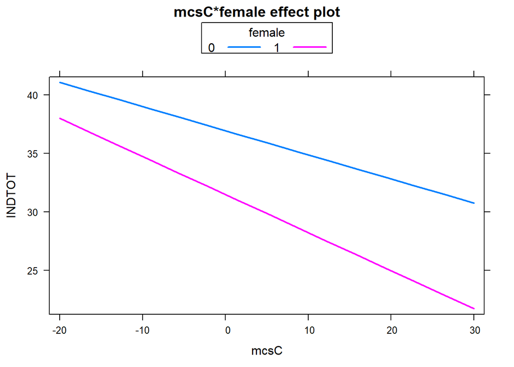

```r
# For this we use the model created above
# m2f
# summary(m2f)

plot(effects::effect("mcsC*female", m2f,
            xlevels=list(female=0:1)),
     multiline=TRUE, ylab="INDTOT", rug=FALSE)
```

## Alternative ANCOVA approach using the `HH` package

```r
# note: to use the ancova() function in the HH
# package, the categorical variable female
# must be of factor class.
class(help2$female)
```

```
## [1] "labelled"
```

```r
help2$femaleF <- as.factor(help2$female)
class(help2$femaleF)
```

```
## [1] "factor"
```

```r
hhaov <- HH::ancova(indtot ~ mcsC * femaleF, data=help2)
```

See summary and associated effect plot from the `HH` package.

```r
hhaov
```

```
## Analysis of Variance Table
##
## Response: indtot
##               Df  Sum Sq Mean Sq F value    Pr(>F)
## mcsC           1  3349.7  3349.7 86.4811 < 2.2e-16 ***
## femaleF        1  2200.3  2200.3 56.8066 2.678e-13 ***
## mcsC:femaleF   1   180.3   180.3  4.6551   0.03149 *
## Residuals    449 17391.3    38.7
## ---
## Signif. codes:  0 '***' 0.001 '**' 0.01 '*' 0.05 '.' 0.1 ' ' 1
```

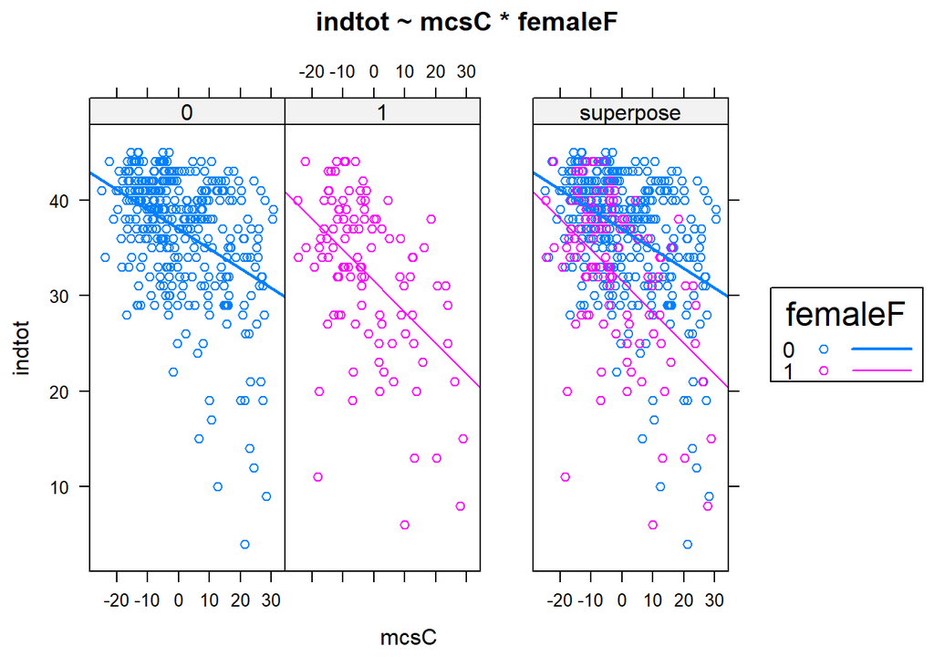

## Plots using the `ggplot2` package

The interaction plots can also be done using `qplot()` function from the `ggplot2` package and we can overlay a smooth regression fit line. NOTE: `ggplot2` should already be loaded when we loaded the `tidyverse` package above.

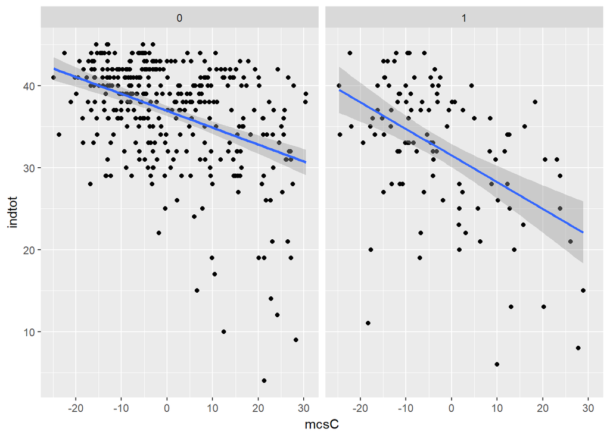

```r
ggplot2::qplot(x=mcsC, y=indtot, facets=~female, data=help2) +
  geom_smooth(method="lm")
```

## Can also use the `sjPlot` package

YOu can learn more about the `sjPlot` package at http://www.strengejacke.de/sjPlot/sjp.int/.

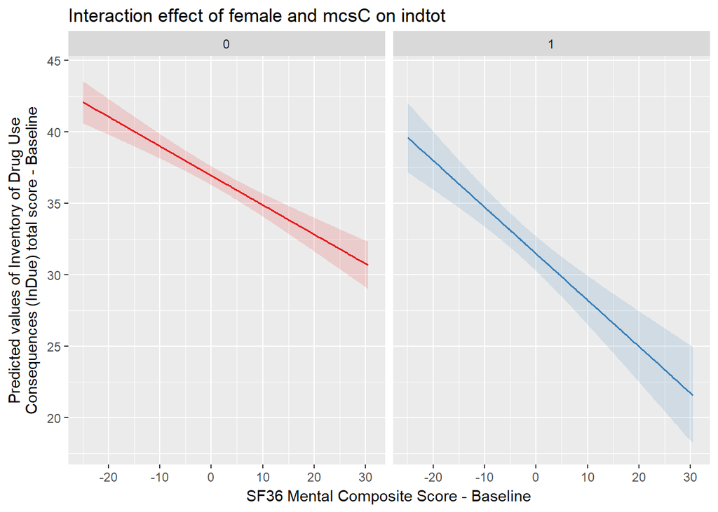

```r
m3f <- lm(indtot ~ female * mcsC, data=help2)

sjp.int(m3f, type="eff",
        show.ci=TRUE,
        facet.grid=TRUE)
```